# Analyzing the Effects of Social and Economic Factors on Students’ Dropout and Academic Success

#### 2.6 First Semester Grade by Target

- Higher first semester grade generally correlates with a higher likelihood of graduating.
- However, some students with relatively high grades (between 10-15) still drop out.

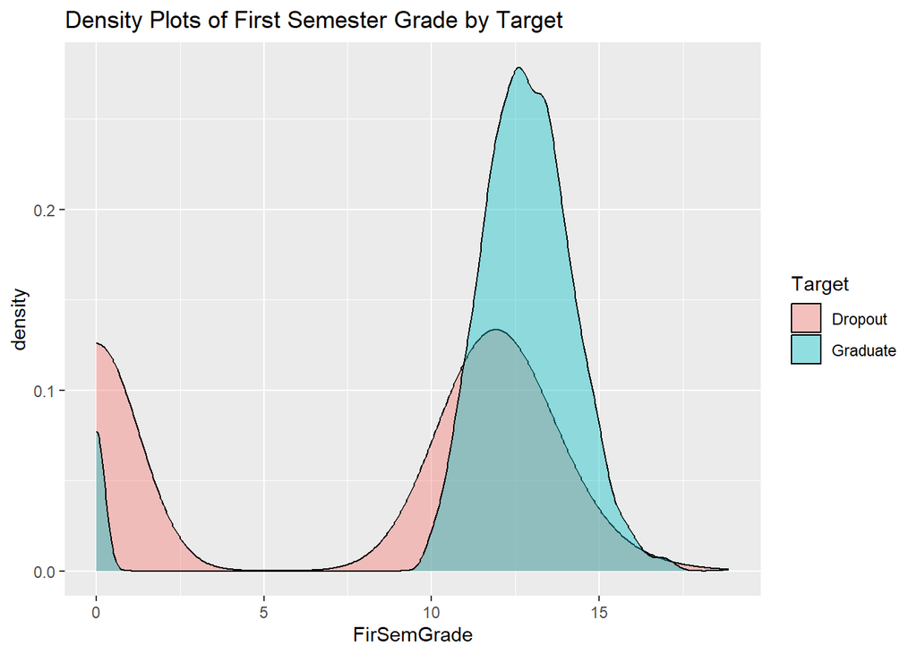

```r
ggplot(ac, aes(x = FirSemGrade, fill = Target)) +
  geom_density(alpha = 0.4) +
  labs(title = "Density Plots of First Semester Grade by Target")
```

#### 2.7 Distribution of Curricular Units: 2nd Semester

- The distribution of curricular units for the second semester is similar to the first semester.
- As with the first semester, the grade is the most significant factor contributing to student dropout, followed by approval and evaluation.

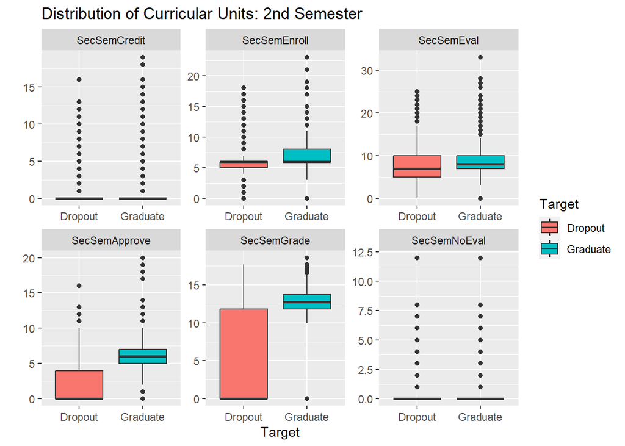

```r
curricular2_boxplot <- ac[, c("Target",
                              "SecSemCredit",
                              "SecSemEnroll",
                              "SecSemEval",
                              "SecSemApprove",
                              "SecSemGrade",
                              "SecSemNoEval")]

curricular2_melt <- melt(curricular2_boxplot, id.vars = "Target")

ggplot(curricular2_melt, aes(x = Target, y = value, fill = Target)) +
  geom_boxplot() +
  facet_wrap(~ variable, scales = "free") +
  labs(title = "Distribution of Curricular Units: 2nd Semester", y = "")
```